# Data Transformation With dplyr

Healthcare Data Science (BIOS 511)

A typical data science project:

[figure not shown]

## Example data

- Available from the nycflights13 package.
- 336,776 flights that departed from New York City in 2013:

```r
library("tidyverse")
# install.packages("nycflights13")
library("nycflights13")
flights
```

```
## # A tibble: 336,776 × 19
##     year month   day dep_time sched_de…¹ dep_d…² arr_t…³ sched…⁴ arr_d…⁵ carrier
##    <int> <int> <int>    <int>      <int>   <dbl>   <int>   <int>   <dbl> <chr>
##  1  2013     1     1      517        515       2     830     819      11 UA
##  2  2013     1     1      533        529       4     850     830      20 UA
##  3  2013     1     1      542        540       2     923     850      33 AA
##  4  2013     1     1      544        545      -1    1004    1022     -18 B6
##  5  2013     1     1      554        600      -6     812     837     -25 DL
##  6  2013     1     1      554        558      -4     740     728      12 UA
##  7  2013     1     1      555        600      -5     913     854      19 B6
##  8  2013     1     1      557        600      -3     709     723     -14 EV
##  9  2013     1     1      557        600      -3     838     846      -8 B6
## 10  2013     1     1      558        600      -2     753     745       8 AA
## # … with 336,766 more rows, 9 more variables: flight <int>, tailnum <chr>,
## #   origin <chr>, dest <chr>, air_time <dbl>, distance <dbl>, hour <dbl>,
## #   minute <dbl>, time_hour <dttm>, and abbreviated variable names
## #   ¹sched_dep_time, ²dep_delay, ³arr_time, ⁴sched_arr_time, ⁵arr_delay
```

## dplyr basics

- Pick observations by their values: `filter()`.
- Reorder the rows: `arrange()`.
- Pick variables by their names: `select()`.
- Create new variables with functions of existing variables: `mutate()`.
- Collapse many values down to a single summary: `summarise()`.

# Manipulate rows (cases)

## `filter()`

- Flights on Jan 1st:

  ```r
  # same as filter(flights, month == 1 & day == 1)
  filter(flights, month == 1, day == 1)
  ```

  ```
  ## # A tibble: 842 × 19
  ##     year month   day dep_time sched_de…¹ dep_d…² arr_t…³ sched…⁴ arr_d…⁵ carrier
  ##    <int> <int> <int>    <int>      <int>   <dbl>   <int>   <int>   <dbl> <chr>
  ##  1  2013     1     1      517        515       2     830     819      11 UA
  ##  2  2013     1     1      533        529       4     850     830      20 UA
  ##  3  2013     1     1      542        540       2     923     850      33 AA
  ##  4  2013     1     1      544        545      -1    1004    1022     -18 B6
  ##  5  2013     1     1      554        600      -6     812     837     -25 DL
  ##  6  2013     1     1      554        558      -4     740     728      12 UA
  ##  7  2013     1     1      555        600      -5     913     854      19 B6
  ##  8  2013     1     1      557        600      -3     709     723     -14 EV
  ##  9  2013     1     1      557        600      -3     838     846      -8 B6
  ## 10  2013     1     1      558        600      -2     753     745       8 AA
  ## # … with 832 more rows, 9 more variables: flight <int>, tailnum <chr>,
  ## #   origin <chr>, dest <chr>, air_time <dbl>, distance <dbl>, hour <dbl>,
  ## #   minute <dbl>, time_hour <dttm>, and abbreviated variable names
  ## #   ¹sched_dep_time, ²dep_delay, ³arr_time, ⁴sched_arr_time, ⁵arr_delay
  ```

- Flights in Nov or Dec:

  ```r
  filter(flights, month == 11 | month == 12)
  ```

  ```
  ## # A tibble: 55,403 × 19
  ##     year month   day dep_time sched_de…¹ dep_d…² arr_t…³ sched…⁴ arr_d…⁵ carrier
  ##    <int> <int> <int>    <int>      <int>   <dbl>   <int>   <int>   <dbl> <chr>
  ##  1  2013    11     1        5       2359       6     352     345       7 B6
  ##  2  2013    11     1       35       2250     105     123    2356      87 B6
  ##  3  2013    11     1      455        500      -5     641     651     -10 US
  ##  4  2013    11     1      539        545      -6     856     827      29 UA
  ##  5  2013    11     1      542        545      -3     831     855     -24 AA
  ##  6  2013    11     1      549        600     -11     912     923     -11 UA
  ##  7  2013    11     1      550        600     -10     705     659       6 US
  ##  8  2013    11     1      554        600      -6     659     701      -2 US
  ##  9  2013    11     1      554        600      -6     826     827      -1 DL
  ## 10  2013    11     1      554        600      -6     749     751      -2 DL
  ## # … with 55,393 more rows, 9 more variables: flight <int>, tailnum <chr>,
  ## #   origin <chr>, dest <chr>, air_time <dbl>, distance <dbl>, hour <dbl>,
  ## #   minute <dbl>, time_hour <dttm>, and abbreviated variable names
  ## #   ¹sched_dep_time, ²dep_delay, ³arr_time, ⁴sched_arr_time, ⁵arr_delay
  ```

## Remove rows with duplicate values

- One row from each month:

  ```r
  distinct(flights, month, .keep_all = TRUE)
  ```

  ```
  ## # A tibble: 12 × 19
  ##     year month   day dep_time sched_de…¹ dep_d…² arr_t…³ sched…⁴ arr_d…⁵ carrier
  ##    <int> <int> <int>    <int>      <int>   <dbl>   <int>   <int>   <dbl> <chr>
  ##  1  2013     1     1      517        515       2     830     819      11 UA
  ##  2  2013    10     1      447        500     -13     614     648     -34 US
  ##  3  2013    11     1        5       2359       6     352     345       7 B6
  ##  4  2013    12     1       13       2359      14     446     445       1 B6
  ##  5  2013     2     1      456        500      -4     652     648       4 US
  ##  6  2013     3     1        4       2159     125     318      56     142 B6
  ##  7  2013     4     1      454        500      -6     636     640      -4 US
  ##  8  2013     5     1        9       1655     434     308    2020     408 VX
  ##  9  2013     6     1        2       2359       3     341     350      -9 B6
  ## 10  2013     7     1        1       2029     212     236    2359     157 B6
  ## 11  2013     8     1       12       2130     162     257      14     163 B6
  ## 12  2013     9     1        9       2359      10     343     340       3 B6
  ## # … with 9 more variables: flight <int>, tailnum <chr>, origin <chr>,
  ## #   dest <chr>, air_time <dbl>, distance <dbl>, hour <dbl>, minute <dbl>,
  ## #   time_hour <dttm>, and abbreviated variable names ¹sched_dep_time,
  ## #   ²dep_delay, ³arr_time, ⁴sched_arr_time, ⁵arr_delay
  ```

## Sample rows

- Randomly select `n` rows:

  ```r
  sample_n(flights, 10, replace = TRUE)
  ```

  ```
  ## # A tibble: 10 × 19
  ##     year month   day dep_time sched_de…¹ dep_d…² arr_t…³ sched…⁴ arr_d…⁵ carrier
  ##    <int> <int> <int>    <int>      <int>   <dbl>   <int>   <int>   <dbl> <chr>
  ##  1  2013     9    20      842        830      12    1026    1018       8 EV
  ##  2  2013     6    15      803        725      38     957     933      24 EV
  ##  3  2013     3     9      558        600      -2     709     733     -24 UA
  ##  4  2013    11    23      853        742      71    1035     924      71 EV
  ##  5  2013     3     9     1719       1720      -1    2005    2040     -35 AA
  ##  6  2013    10    17     1652       1700      -8    1744    1815     -31 US
  ##  7  2013     1    31       NA       1703      NA      NA    1810      NA EV
  ##  8  2013     5    25     1126       1130      -4    1250    1311     -21 EV
  ##  9  2013     5    15     1406       1415      -9    1555    1610     -15 MQ
  ## 10  2013     6    22      603        605      -2     713     721      -8 EV
  ## # … with 9 more variables: flight <int>, tailnum <chr>, origin <chr>,
  ## #   dest <chr>, air_time <dbl>, distance <dbl>, hour <dbl>, minute <dbl>,
  ## #   time_hour <dttm>, and abbreviated variable names ¹sched_dep_time,
  ## #   ²dep_delay, ³arr_time, ⁴sched_arr_time, ⁵arr_delay
  ```

- Randomly select fraction of rows:

  ```r
  sample_frac(flights, 0.1, replace = TRUE)
  ```

  ```
  ## # A tibble: 33,678 × 19
  ##     year month   day dep_time sched_de…¹ dep_d…² arr_t…³ sched…⁴ arr_d…⁵ carrier
  ##    <int> <int> <int>    <int>      <int>   <dbl>   <int>   <int>   <dbl> <chr>
  ##  1  2013    11    17     1143       1154     -11    1418    1409       9 EV
  ##  2  2013     1    30      825        830      -5    1020    1023      -3 9E
  ##  3  2013     2    27     1039       1000      39    1315    1239      36 DL
  ##  4  2013    12    27     1628       1619       9    1737    1737       0 EV
  ##  5  2013     1    13     1955       2000      -5    2127    2117      10 US
  ##  6  2013    10    23     1443       1450      -7    1637    1645      -8 MQ
  ##  7  2013     9    11     1102       1105      -3    1408    1418     -10 DL
  ##  8  2013    12     4     1955       2000      -5    2347    2325      22 VX
  ##  9  2013    11     7     1600       1430      90    1738    1609      89 UA
  ## 10  2013     2     6     1637       1640      -3    1851    1850       1 MQ
  ## # … with 33,668 more rows, 9 more variables: flight <int>, tailnum <chr>,
  ## #   origin <chr>, dest <chr>, air_time <dbl>, distance <dbl>, hour <dbl>,
  ## #   minute <dbl>, time_hour <dttm>, and abbreviated variable names
  ## #   ¹sched_dep_time, ²dep_delay, ³arr_time, ⁴sched_arr_time, ⁵arr_delay
  ```

## Select rows by position

- Select rows by position:

  ```r
  slice(flights, 1:5)
  ```

  ```
  ## # A tibble: 5 × 19
  ##    year month   day dep_time sched_dep…¹ dep_d…² arr_t…³ sched…⁴ arr_d…⁵ carrier
  ##   <int> <int> <int>    <int>       <int>   <dbl>   <int>   <int>   <dbl> <chr>
  ## 1  2013     1     1      517         515       2     830     819      11 UA
  ## 2  2013     1     1      533         529       4     850     830      20 UA
  ## 3  2013     1     1      542         540       2     923     850      33 AA
  ## 4  2013     1     1      544         545      -1    1004    1022     -18 B6
  ## 5  2013     1     1      554         600      -6     812     837     -25 DL
  ## # … with 9 more variables: flight <int>, tailnum <chr>, origin <chr>,
  ## #   dest <chr>, air_time <dbl>, distance <dbl>, hour <dbl>, minute <dbl>,
  ## #   time_hour <dttm>, and abbreviated variable names ¹sched_dep_time,
  ## #   ²dep_delay, ³arr_time, ⁴sched_arr_time, ⁵arr_delay
  ```

- Top `n` rows:

  ```r
  top_n(flights, 5)
  ```

  ```
  ## # A tibble: 5 × 19
  ##    year month   day dep_time sched_dep…¹ dep_d…² arr_t…³ sched…⁴ arr_d…⁵ carrier
  ##   <int> <int> <int>    <int>       <int>   <dbl>   <int>   <int>   <dbl> <chr>
  ## 1  2013    12    31       13        2359      14     439     437       2 B6
  ## 2  2013    12    31       18        2359      19     449     444       5 DL
  ## 3  2013    12    31     2328        2330      -2     412     409       3 B6
  ## 4  2013    12    31     2355        2359      -4     430     440     -10 B6
  ## 5  2013    12    31     2356        2359      -3     436     445      -9 B6
  ## # … with 9 more variables: flight <int>, tailnum <chr>, origin <chr>,
  ## #   dest <chr>, air_time <dbl>, distance <dbl>, hour <dbl>, minute <dbl>,
  ## #   time_hour <dttm>, and abbreviated variable names ¹sched_dep_time,
  ## #   ²dep_delay, ³arr_time, ⁴sched_arr_time, ⁵arr_delay
  ```

```r
top_n(flights, 5, distance)
```

```
## # A tibble: 342 × 19
##     year month   day dep_time sched_de…¹ dep_d…² arr_t…³ sched…⁴ arr_d…⁵ carrier
##    <int> <int> <int>    <int>      <int>   <dbl>   <int>   <int>   <dbl> <chr>
##  1  2013     1     1      857        900      -3    1516    1530     -14 HA
##  2  2013     1     2      909        900       9    1525    1530      -5 HA
##  3  2013     1     3      914        900      14    1504    1530     -26 HA
##  4  2013     1     4      900        900       0    1516    1530     -14 HA
##  5  2013     1     5      858        900      -2    1519    1530     -11 HA
##  6  2013     1     6     1019        900      79    1558    1530      28 HA
##  7  2013     1     7     1042        900     102    1620    1530      50 HA
##  8  2013     1     8      901        900       1    1504    1530     -26 HA
##  9  2013     1     9      641        900    1301    1242    1530    1272 HA
## 10  2013     1    10      859        900      -1    1449    1530     -41 HA
## # … with 332 more rows, 9 more variables: flight <int>, tailnum <chr>,
## #   origin <chr>, dest <chr>, air_time <dbl>, distance <dbl>, hour <dbl>,
## #   minute <dbl>, time_hour <dttm>, and abbreviated variable names
## #   ¹sched_dep_time, ²dep_delay, ³arr_time, ⁴sched_arr_time, ⁵arr_delay
```

## Arrange rows with `arrange()`

- Sort in ascending order:

  ```r
  arrange(flights, year, month, day)
  ```

  ```
  ## # A tibble: 336,776 × 19
  ##     year month   day dep_time sched_de…¹ dep_d…² arr_t…³ sched…⁴ arr_d…⁵ carrier
  ##    <int> <int> <int>    <int>      <int>   <dbl>   <int>   <int>   <dbl> <chr>
  ##  1  2013     1     1      517        515       2     830     819      11 UA
  ##  2  2013     1     1      533        529       4     850     830      20 UA
  ##  3  2013     1     1      542        540       2     923     850      33 AA
  ##  4  2013     1     1      544        545      -1    1004    1022     -18 B6
  ##  5  2013     1     1      554        600      -6     812     837     -25 DL
  ##  6  2013     1     1      554        558      -4     740     728      12 UA
  ##  7  2013     1     1      555        600      -5     913     854      19 B6
  ##  8  2013     1     1      557        600      -3     709     723     -14 EV
  ##  9  2013     1     1      557        600      -3     838     846      -8 B6
  ## 10  2013     1     1      558        600      -2     753     745       8 AA
  ## # … with 336,766 more rows, 9 more variables: flight <int>, tailnum <chr>,
  ## #   origin <chr>, dest <chr>, air_time <dbl>, distance <dbl>, hour <dbl>,
  ## #   minute <dbl>, time_hour <dttm>, and abbreviated variable names
  ## #   ¹sched_dep_time, ²dep_delay, ³arr_time, ⁴sched_arr_time, ⁵arr_delay
  ```

- Sort in descending order:

  ```r
  arrange(flights, desc(arr_delay))
  ```

  ```
  ## # A tibble: 336,776 × 19
  ##     year month   day dep_time sched_de…¹ dep_d…² arr_t…³ sched…⁴ arr_d…⁵ carrier
  ##    <int> <int> <int>    <int>      <int>   <dbl>   <int>   <int>   <dbl> <chr>
  ##  1  2013     1     9      641        900    1301    1242    1530    1272 HA
  ##  2  2013     6    15     1432       1935    1137    1607    2120    1127 MQ
  ##  3  2013     1    10     1121       1635    1126    1239    1810    1109 MQ
  ##  4  2013     9    20     1139       1845    1014    1457    2210    1007 AA
  ##  5  2013     7    22      845       1600    1005    1044    1815     989 MQ
  ##  6  2013     4    10     1100       1900     960    1342    2211     931 DL
  ##  7  2013     3    17     2321        810     911     135    1020     915 DL
  ##  8  2013     7    22     2257        759     898     121    1026     895 DL
  ##  9  2013    12     5      756       1700     896    1058    2020     878 AA
  ## 10  2013     5     3     1133       2055     878    1250    2215     875 MQ
  ## # … with 336,766 more rows, 9 more variables: flight <int>, tailnum <chr>,
  ## #   origin <chr>, dest <chr>, air_time <dbl>, distance <dbl>, hour <dbl>,
  ## #   minute <dbl>, time_hour <dttm>, and abbreviated variable names
  ## #   ¹sched_dep_time, ²dep_delay, ³arr_time, ⁴sched_arr_time, ⁵arr_delay
  ```

# Manipulate columns (variables)

## Select columns with `select()`

- Select columns by variable name:

  ```r
  select(flights, year, month, day)
  ```

  ```
  ## # A tibble: 336,776 × 3
  ##     year month   day
  ##    <int> <int> <int>
  ##  1  2013     1     1
  ##  2  2013     1     1
  ##  3  2013     1     1
  ##  4  2013     1     1
  ##  5  2013     1     1
  ##  6  2013     1     1
  ##  7  2013     1     1
  ##  8  2013     1     1
  ##  9  2013     1     1
  ## 10  2013     1     1
  ## # … with 336,766 more rows
  ```

- Select columns between two variables:

  ```r
  select(flights, year:day)
  ```

  ```
  ## # A tibble: 336,776 × 3
  ##     year month   day
  ##    <int> <int> <int>
  ##  1  2013     1     1
  ##  2  2013     1     1
  ##  3  2013     1     1
  ##  4  2013     1     1
  ##  5  2013     1     1
  ##  6  2013     1     1
  ##  7  2013     1     1
  ##  8  2013     1     1
  ##  9  2013     1     1
  ## 10  2013     1     1
  ## # … with 336,766 more rows
  ```

- Select columns *except* those between two variables:

  ```r
  select(flights, -(year:day))
  ```

  ```
  ## # A tibble: 336,776 × 16
  ##    dep_t…¹ sched…² dep_d…³ arr_t…⁴ sched…⁵ arr_d…⁶ carrier flight tailnum origin
  ##      <int>   <int>   <dbl>   <int>   <int>   <dbl> <chr>    <int> <chr>   <chr>
  ##  1     517     515       2     830     819      11 UA        1545 N14228  EWR
  ##  2     533     529       4     850     830      20 UA        1714 N24211  LGA
  ##  3     542     540       2     923     850      33 AA        1141 N619AA  JFK
  ##  4     544     545      -1    1004    1022     -18 B6         725 N804JB  JFK
  ##  5     554     600      -6     812     837     -25 DL         461 N668DN  LGA
  ##  6     554     558      -4     740     728      12 UA        1696 N39463  EWR
  ##  7     555     600      -5     913     854      19 B6         507 N516JB  EWR
  ##  8     557     600      -3     709     723     -14 EV        5708 N829AS  LGA
  ##  9     557     600      -3     838     846      -8 B6          79 N593JB  JFK
  ## 10     558     600      -2     753     745       8 AA         301 N3ALAA  LGA
  ## # … with 336,766 more rows, 6 more variables: dest <chr>, air_time <dbl>,
  ## #   distance <dbl>, hour <dbl>, minute <dbl>, time_hour <dttm>, and abbreviated
  ## #   variable names ¹dep_time, ²sched_dep_time, ³dep_delay, ⁴arr_time,
  ## #   ⁵sched_arr_time, ⁶arr_delay
  ```

- Select columns by positions:

  ```r
  select(flights, seq(1, 10, by = 2))
  ```

  ```
  ## # A tibble: 336,776 × 5
  ##     year   day sched_dep_time arr_time arr_delay
  ##    <int> <int>          <int>    <int>     <dbl>
  ##  1  2013     1            515      830        11
  ##  2  2013     1            529      850        20
  ##  3  2013     1            540      923        33
  ##  4  2013     1            545     1004       -18
  ##  5  2013     1            600      812       -25
  ##  6  2013     1            558      740        12
  ##  7  2013     1            600      913        19
  ##  8  2013     1            600      709       -14
  ##  9  2013     1            600      838        -8
  ## 10  2013     1            600      753         8
  ## # … with 336,766 more rows
  ```

- Move variables to the start of data frame:

  ```r
  select(flights, time_hour, air_time, everything())
  ```

  ```
  ## # A tibble: 336,776 × 19
  ##    time_hour           air_t…¹  year month   day dep_t…² sched…³ dep_d…⁴ arr_t…⁵
  ##    <dttm>                <dbl> <int> <int> <int>   <int>   <int>   <dbl>   <int>
  ##  1 2013-01-01 05:00:00     227  2013     1     1     517     515       2     830
  ##  2 2013-01-01 05:00:00     227  2013     1     1     533     529       4     850
  ##  3 2013-01-01 05:00:00     160  2013     1     1     542     540       2     923
  ##  4 2013-01-01 05:00:00     183  2013     1     1     544     545      -1    1004
  ##  5 2013-01-01 06:00:00     116  2013     1     1     554     600      -6     812
  ##  6 2013-01-01 05:00:00     150  2013     1     1     554     558      -4     740
  ##  7 2013-01-01 06:00:00     158  2013     1     1     555     600      -5     913
  ##  8 2013-01-01 06:00:00      53  2013     1     1     557     600      -3     709
  ##  9 2013-01-01 06:00:00     140  2013     1     1     557     600      -3     838
  ## 10 2013-01-01 06:00:00     138  2013     1     1     558     600      -2     753
  ## # … with 336,766 more rows, 10 more variables: sched_arr_time <int>,
  ## #   arr_delay <dbl>, carrier <chr>, flight <int>, tailnum <chr>, origin <chr>,
  ## #   dest <chr>, distance <dbl>, hour <dbl>, minute <dbl>, and abbreviated
  ## #   variable names ¹air_time, ²dep_time, ³sched_dep_time, ⁴dep_delay, ⁵arr_time
  ```

```r
select(flights, 19,15,everything())
```

```
## # A tibble: 336,776 × 19
##    time_hour           air_t…¹  year month   day dep_t…² sched…³ dep_d…⁴ arr_t…⁵
##    <dttm>                <dbl> <int> <int> <int>   <int>   <int>   <dbl>   <int>
##  1 2013-01-01 05:00:00     227  2013     1     1     517     515       2     830
##  2 2013-01-01 05:00:00     227  2013     1     1     533     529       4     850
##  3 2013-01-01 05:00:00     160  2013     1     1     542     540       2     923
##  4 2013-01-01 05:00:00     183  2013     1     1     544     545      -1    1004
##  5 2013-01-01 06:00:00     116  2013     1     1     554     600      -6     812
##  6 2013-01-01 05:00:00     150  2013     1     1     554     558      -4     740
##  7 2013-01-01 06:00:00     158  2013     1     1     555     600      -5     913
##  8 2013-01-01 06:00:00      53  2013     1     1     557     600      -3     709
##  9 2013-01-01 06:00:00     140  2013     1     1     557     600      -3     838
## 10 2013-01-01 06:00:00     138  2013     1     1     558     600      -2     753
## # … with 336,766 more rows, 10 more variables: sched_arr_time <int>,
## #   arr_delay <dbl>, carrier <chr>, flight <int>, tailnum <chr>, origin <chr>,
## #   dest <chr>, distance <dbl>, hour <dbl>, minute <dbl>, and abbreviated
## #   variable names ¹air_time, ²dep_time, ³sched_dep_time, ⁴dep_delay, ⁵arr_time
```

The selection Helper functions help match a pattern

starts_with(“abc”): matches names that begin with “abc”.

```r
select(flights, starts_with("dep"))
```

```
## # A tibble: 336,776 × 2
##    dep_time dep_delay
##       <int>     <dbl>
##  1      517         2
##  2      533         4
##  3      542         2
##  4      544        -1
##  5      554        -6
##  6      554        -4
##  7      555        -5
##  8      557        -3
##  9      557        -3
## 10      558        -2
## # … with 336,766 more rows
```

ends_with(“xyz”): matches names that end with “xyz”.

```r
select(flights, ends_with("time"))
```

```
## # A tibble: 336,776 × 5
##    dep_time sched_dep_time arr_time sched_arr_time air_time
##       <int>          <int>    <int>          <int>    <dbl>
##  1      517            515      830            819      227
##  2      533            529      850            830      227
##  3      542            540      923            850      160
##  4      544            545     1004           1022      183
##  5      554            600      812            837      116
##  6      554            558      740            728      150
##  7      555            600      913            854      158
##  8      557            600      709            723       53
##  9      557            600      838            846      140
## 10      558            600      753            745      138
## # … with 336,766 more rows
```

contains(“ijk”): matches names that contain “ijk”

```r
select(flights, contains("arr"))
```

```
## # A tibble: 336,776 × 4
##    arr_time sched_arr_time arr_delay carrier
##       <int>          <int>     <dbl> <chr>
##  1      830            819        11 UA
##  2      850            830        20 UA
##  3      923            850        33 AA
##  4     1004           1022       -18 B6
##  5      812            837       -25 DL
##  6      740            728        12 UA
##  7      913            854        19 B6
##  8      709            723       -14 EV
##  9      838            846        -8 B6
## 10      753            745         8 AA
## # … with 336,766 more rows
```

matches(“(.)\1”): selects variables that match a regular expression.

```r
select(flights, matches("sched"))
```

```
## # A tibble: 336,776 × 2
##    sched_dep_time sched_arr_time
##             <int>          <int>
##  1            515            819
##  2            529            830
##  3            540            850
##  4            545           1022
##  5            600            837
##  6            558            728
##  7            600            854
##  8            600            723
##  9            600            846
## 10            600            745
## # … with 336,766 more rows
```

Differences between matches function and contains function: Matches function can match a regular expression while contains function can only match a literal string.

```r
select(flights, matches("sched"))
```

```
## # A tibble: 336,776 × 2
##    sched_dep_time sched_arr_time
##             <int>          <int>
##  1            515            819
##  2            529            830
##  3            540            850
##  4            545           1022
##  5            600            837
##  6            558            728
##  7            600            854
##  8            600            723
##  9            600            846
## 10            600            745
## # … with 336,766 more rows
```

```r
select(flights, contains("sched"))
```

```
## # A tibble: 336,776 × 2
##    sched_dep_time sched_arr_time
##             <int>          <int>
##  1            515            819
##  2            529            830
##  3            540            850
##  4            545           1022
##  5            600            837
##  6            558            728
##  7            600            854
##  8            600            723
##  9            600            846
## 10            600            745
## # … with 336,766 more rows
```

```r
select(flights, contains('arr_\\w'))
```

```
## # A tibble: 336,776 × 0
```

```r
select(flights,matches('arr_\\w'))
```

```
## # A tibble: 336,776 × 3
##    arr_time sched_arr_time arr_delay
##       <int>          <int>     <dbl>
##  1      830            819        11
##  2      850            830        20
##  3      923            850        33
##  4     1004           1022       -18
##  5      812            837       -25
##  6      740            728        12
##  7      913            854        19
##  8      709            723       -14
##  9      838            846        -8
## 10      753            745         8
## # … with 336,766 more rows
```

num_range(“x”, 1:3)`: matches x1, x2 and x3.

```r
df=data.frame(col1=1:5,col2=2:6,col3=4,col4=9,col5=67)
df
```

```
##   col1 col2 col3 col4 col5
## 1    1    2    4    9   67
## 2    2    3    4    9   67
## 3    3    4    4    9   67
## 4    4    5    4    9   67
## 5    5    6    4    9   67
```

```r
select(df, num_range('col',2:4))
```

```
##   col2 col3 col4
## 1    2    4    9
## 2    3    4    9
## 3    4    4    9
## 4    5    4    9
## 5    6    4    9
```

`one_of()`

```r
select(flights, one_of(c("dep", "arr_delay", "sched_dep_time")))
```

```
## # A tibble: 336,776 × 2
##    arr_delay sched_dep_time
##        <dbl>          <int>
##  1        11            515
##  2        20            529
##  3        33            540
##  4       -18            545
##  5       -25            600
##  6        12            558
##  7        19            600
##  8       -14            600
##  9        -8            600
## 10         8            600
## # … with 336,766 more rows
```

- Helper functions.
  - `starts_with("abc")`: matches names that begin with “abc”.
  - `ends_with("xyz")`: matches names that end with “xyz”.
  - `contains("ijk")`: matches names that contain “ijk”.
  - `matches("(.)\\1")`: selects variables that match a regular expression.
  - `num_range("x", 1:3)`: matches x1, x2 and x3.
  - `one_of()`

## Add new variables with `mutate()`

- Add variables `gain` and `speed`:

  ```r
  flights_sml <-
    select(flights, year:day, ends_with("delay"), distance, air_time)
  ```

  mutate function adds new variable and also keeps the original variables.

  ```r
  mutate(flights_sml,
    gain = arr_delay - dep_delay,
    speed = distance / air_time * 60
  )
  ```

  ```
  ## # A tibble: 336,776 × 9
  ##     year month   day dep_delay arr_delay distance air_time  gain speed
  ##    <int> <int> <int>     <dbl>     <dbl>    <dbl>    <dbl> <dbl> <dbl>
  ##  1  2013     1     1         2        11     1400      227     9  370.
  ##  2  2013     1     1         4        20     1416      227    16  374.
  ##  3  2013     1     1         2        33     1089      160    31  408.
  ##  4  2013     1     1        -1       -18     1576      183   -17  517.
  ##  5  2013     1     1        -6       -25      762      116   -19  394.
  ##  6  2013     1     1        -4        12      719      150    16  288.
  ##  7  2013     1     1        -5        19     1065      158    24  404.
  ##  8  2013     1     1        -3       -14      229       53   -11  259.
  ##  9  2013     1     1        -3        -8      944      140    -5  405.
  ## 10  2013     1     1        -2         8      733      138    10  319.
  ## # … with 336,766 more rows
  ```

- Refer to columns that you’ve just created:

  ```r
  mutate(flights_sml,
    gain = arr_delay - dep_delay,
    hours = air_time / 60,
    gain_per_hour = gain / hours
  )
  ```

  ```
  ## # A tibble: 336,776 × 10
  ##     year month   day dep_delay arr_delay distance air_time  gain hours gain_pe…¹
  ##    <int> <int> <int>     <dbl>     <dbl>    <dbl>    <dbl> <dbl> <dbl>     <dbl>
  ##  1  2013     1     1         2        11     1400      227     9 3.78       2.38
  ##  2  2013     1     1         4        20     1416      227    16 3.78       4.23
  ##  3  2013     1     1         2        33     1089      160    31 2.67      11.6
  ##  4  2013     1     1        -1       -18     1576      183   -17 3.05      -5.57
  ##  5  2013     1     1        -6       -25      762      116   -19 1.93      -9.83
  ##  6  2013     1     1        -4        12      719      150    16 2.5        6.4
  ##  7  2013     1     1        -5        19     1065      158    24 2.63       9.11
  ##  8  2013     1     1        -3       -14      229       53   -11 0.883    -12.5
  ##  9  2013     1     1        -3        -8      944      140    -5 2.33      -2.14
  ## 10  2013     1     1        -2         8      733      138    10 2.3        4.35
  ## # … with 336,766 more rows, and abbreviated variable name ¹gain_per_hour
  ```

- Only keep the new variables by `transmute()`:

  ```r
  transmute(flights,
    gain = arr_delay - dep_delay,
    hours = air_time / 60,
    gain_per_hour = gain / hours
  )
  ```

  ```
  ## # A tibble: 336,776 × 3
  ##     gain hours gain_per_hour
  ##    <dbl> <dbl>         <dbl>
  ##  1     9 3.78           2.38
  ##  2    16 3.78           4.23
  ##  3    31 2.67          11.6
  ##  4   -17 3.05          -5.57
  ##  5   -19 1.93          -9.83
  ##  6    16 2.5            6.4
  ##  7    24 2.63           9.11
  ##  8   -11 0.883        -12.5
  ##  9    -5 2.33          -2.14
  ## 10    10 2.3            4.35
  ## # … with 336,766 more rows
  ```

- `mutate_all()`: apply funs to all columns.

  ```r
  mutate_all(data, funs(log(.), log2(.)))
  ```

- `mutate_at()`: apply funs to specific columns.

  ```r
  df1<-mutate(flights_sml, gain = arr_delay - dep_delay, speed = distance / air_time * 60 )
  mutate_at(df1, vars(speed), funs(round))
  ```

- `mutate_if()`: apply funs of one type

  ```r
  mutate_if(df1, is.numeric, funs(log(.)))
  ```

# Summaries

## Summaries with `summarise()`

- Mean of a variable:

  ```r
  summarise(flights, delay = mean(dep_delay, na.rm = TRUE))
  ```

  ```
  ## # A tibble: 1 × 1
  ##   delay
  ##   <dbl>
  ## 1  12.6
  ```

```r
    mean(flights$dep_delay, na.rm = TRUE)
```

```
## [1] 12.63907
```

- Convert a tibble into a grouped tibble:

  ```r
  (by_day <- group_by(flights, year, month, day))
  ```

  ```
  ## # A tibble: 336,776 × 19
  ## # Groups:   year, month, day [365]
  ##     year month   day dep_time sched_de…¹ dep_d…² arr_t…³ sched…⁴ arr_d…⁵ carrier
  ##    <int> <int> <int>    <int>      <int>   <dbl>   <int>   <int>   <dbl> <chr>
  ##  1  2013     1     1      517        515       2     830     819      11 UA
  ##  2  2013     1     1      533        529       4     850     830      20 UA
  ##  3  2013     1     1      542        540       2     923     850      33 AA
  ##  4  2013     1     1      544        545      -1    1004    1022     -18 B6
  ##  5  2013     1     1      554        600      -6     812     837     -25 DL
  ##  6  2013     1     1      554        558      -4     740     728      12 UA
  ##  7  2013     1     1      555        600      -5     913     854      19 B6
  ##  8  2013     1     1      557        600      -3     709     723     -14 EV
  ##  9  2013     1     1      557        600      -3     838     846      -8 B6
  ## 10  2013     1     1      558        600      -2     753     745       8 AA
  ## # … with 336,766 more rows, 9 more variables: flight <int>, tailnum <chr>,
  ## #   origin <chr>, dest <chr>, air_time <dbl>, distance <dbl>, hour <dbl>,
  ## #   minute <dbl>, time_hour <dttm>, and abbreviated variable names
  ## #   ¹sched_dep_time, ²dep_delay, ³arr_time, ⁴sched_arr_time, ⁵arr_delay
  ```

- Grouped summaries:

  ```r
  summarise(by_day, delay = mean(dep_delay, na.rm = TRUE))
  ```

  ```
  ## # A tibble: 365 × 4
  ## # Groups:   year, month [12]
  ##     year month   day delay
  ##    <int> <int> <int> <dbl>
  ##  1  2013     1     1 11.5
  ##  2  2013     1     2 13.9
  ##  3  2013     1     3 11.0
  ##  4  2013     1     4  8.95
  ##  5  2013     1     5  5.73
  ##  6  2013     1     6  7.15
  ##  7  2013     1     7  5.42
  ##  8  2013     1     8  2.55
  ##  9  2013     1     9  2.28
  ## 10  2013     1    10  2.84
  ## # … with 355 more rows
  ```

## Pipe

- Consider following analysis:

  ```r
  by_dest <- group_by(flights, dest)
  delay <- summarise(by_dest, count = n(), # n() - Context dependent expressions: gives the current group size
    dist = mean(distance, na.rm = TRUE),
    delay = mean(arr_delay, na.rm = TRUE)
  )
  (delay <- filter(delay, count > 20, dest != "HNL"))
  ```

  ```
  ## # A tibble: 96 × 4
  ##    dest  count  dist delay
  ##    <chr> <int> <dbl> <dbl>
  ##  1 ABQ     254 1826   4.38
  ##  2 ACK     265  199   4.85
  ##  3 ALB     439  143  14.4
  ##  4 ATL   17215  757. 11.3
  ##  5 AUS    2439 1514.  6.02
  ##  6 AVL     275  584.  8.00
  ##  7 BDL     443  116   7.05
  ##  8 BGR     375  378   8.03
  ##  9 BHM     297  866. 16.9
  ## 10 BNA    6333  758. 11.8
  ## # … with 86 more rows
  ```

  That leads to two problems:
1. The code is cluttered with unimportant names
2. You have to carefully increment the suffix on each line.

```r
foo_foo_1 <- hop(foo_foo, through = forest)
foo_foo_2 <- scoop(foo_foo_1, up = field_mice)
foo_foo_3 <- bop(foo_foo_2, on = head)
```

- Cleaner code using pipe `%>%`:

  ```r
  (delays <- flights %>%
    group_by(dest) %>%
    summarise(
      count = n(),
      dist = mean(distance, na.rm = TRUE),
      delay = mean(arr_delay, na.rm = TRUE)
    ) %>%
    filter(count > 20, dest != "HNL"))
  ```

  ```
  ## # A tibble: 96 × 4
  ##    dest  count  dist delay
  ##    <chr> <int> <dbl> <dbl>
  ##  1 ABQ     254 1826   4.38
  ##  2 ACK     265  199   4.85
  ##  3 ALB     439  143  14.4
  ##  4 ATL   17215  757. 11.3
  ##  5 AUS    2439 1514.  6.02
  ##  6 AVL     275  584.  8.00
  ##  7 BDL     443  116   7.05
  ##  8 BGR     375  378   8.03
  ##  9 BHM     297  866. 16.9
  ## 10 BNA    6333  758. 11.8
  ## # … with 86 more rows
  ```

- Unfortunately ggplot2 does **not** use pipe.

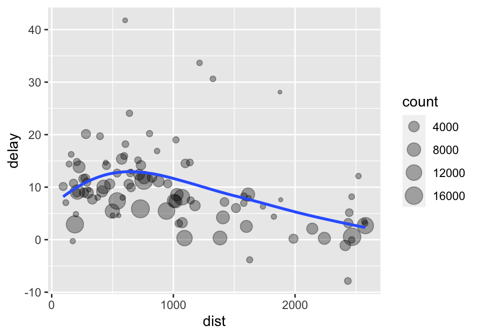

  ```r
  ggplot(data = delays, mapping = aes(x = dist, y = delay)) +
    geom_point(aes(size = count), alpha = 1/3) + geom_smooth(se = FALSE)
  ```

## Other summary functions

- Location: `mean(x)`, `median(x)`.

  ```r
  not_cancelled <- flights %>% filter(!is.na(dep_delay), !is.na(arr_delay))
  ```

  ```r
  not_cancelled %>%
    group_by(year, month, day) %>%
    summarise(
      avg_delay1 = mean(arr_delay),
      avg_delay2 = mean(arr_delay[arr_delay > 0]) # the average positive delay
    )
  ```

  ```
  ## # A tibble: 365 × 5
  ## # Groups:   year, month [12]
  ##     year month   day avg_delay1 avg_delay2
  ##    <int> <int> <int>      <dbl>      <dbl>
  ##  1  2013     1     1     12.7         32.5
  ##  2  2013     1     2     12.7         32.0
  ##  3  2013     1     3      5.73        27.7
  ##  4  2013     1     4     -1.93        28.3
  ##  5  2013     1     5     -1.53        22.6
  ##  6  2013     1     6      4.24        24.4
  ##  7  2013     1     7     -4.95        27.8
  ##  8  2013     1     8     -3.23        20.8
  ##  9  2013     1     9     -0.264       25.6
  ## 10  2013     1    10     -5.90        27.3
  ## # … with 355 more rows
  ```

- Spread: `sd(x)`, `IQR(x)`, `mad(x)`.

  ```r
  not_cancelled %>%
    group_by(dest) %>%
    summarise(distance_sd = sd(distance)) %>%
    arrange(desc(distance_sd))
  ```

  ```
  ## # A tibble: 104 × 2
  ##    dest  distance_sd
  ##    <chr>       <dbl>
  ##  1 EGE         10.5
  ##  2 SAN         10.4
  ##  3 SFO         10.2
  ##  4 HNL         10.0
  ##  5 SEA          9.98
  ##  6 LAS          9.91
  ##  7 PDX          9.87
  ##  8 PHX          9.86
  ##  9 LAX          9.66
  ## 10 IND          9.46
  ## # … with 94 more rows
  ```

- Rank: `min(x)`, `quantile(x, 0.25)`, `max(x)`.

  ```r
  # When do the first and last flights leave each day?
  not_cancelled %>%
    group_by(year, month, day) %>%
    summarise(
      first = min(dep_time),
      last = max(dep_time)
    )
  ```

  ```
  ## # A tibble: 365 × 5
  ## # Groups:   year, month [12]
  ##     year month   day first  last
  ##    <int> <int> <int> <int> <int>
  ##  1  2013     1     1   517  2356
  ##  2  2013     1     2    42  2354
  ##  3  2013     1     3    32  2349
  ##  4  2013     1     4    25  2358
  ##  5  2013     1     5    14  2357
  ##  6  2013     1     6    16  2355
  ##  7  2013     1     7    49  2359
  ##  8  2013     1     8   454  2351
  ##  9  2013     1     9     2  2252
  ## 10  2013     1    10     3  2320
  ## # … with 355 more rows
  ```

- Position: `first(x)`, `nth(x, 2)`, `last(x)`.

  ```r
  not_cancelled %>%
    group_by(year, month, day) %>%
    summarise(
      first_dep = first(dep_time),     # Extract the first value from a vector
      last_dep = last(dep_time)     # Extract the last value from a vector
    )
  ```

  ```
  ## # A tibble: 365 × 5
  ## # Groups:   year, month [12]
  ##     year month   day first_dep last_dep
  ##    <int> <int> <int>     <int>    <int>
  ##  1  2013     1     1       517     2356
  ##  2  2013     1     2        42     2354
  ##  3  2013     1     3        32     2349
  ##  4  2013     1     4        25     2358
  ##  5  2013     1     5        14     2357
  ##  6  2013     1     6        16     2355
  ##  7  2013     1     7        49     2359
  ##  8  2013     1     8       454     2351
  ##  9  2013     1     9         2     2252
  ## 10  2013     1    10         3     2320
  ## # … with 355 more rows
  ```

- Count: `n(x)`, `sum(!is.na(x))`, `n_distinct(x)`.

  ```r
  # Which destinations have the most carriers (Two-letter abbreviation of the airline's name)?
  not_cancelled %>%
    group_by(dest) %>%
    summarise(carriers = n_distinct(carrier)) %>%     # Efficiently count the number of unique values in a set of vectors
    arrange(desc(carriers))
  ```

  ```
  ## # A tibble: 104 × 2
  ##    dest  carriers
  ##    <chr>    <int>
  ##  1 ATL          7
  ##  2 BOS          7
  ##  3 CLT          7
  ##  4 ORD          7
  ##  5 TPA          7
  ##  6 AUS          6
  ##  7 DCA          6
  ##  8 DTW          6
  ##  9 IAD          6
  ## 10 MSP          6
  ## # … with 94 more rows
  ```

- ```r
  not_cancelled %>%
    count(dest)
  ```

  ```
  ## # A tibble: 104 × 2
  ##    dest      n
  ##    <chr> <int>
  ##  1 ABQ     254
  ##  2 ACK     264
  ##  3 ALB     418
  ##  4 ANC       8
  ##  5 ATL   16837
  ##  6 AUS    2411
  ##  7 AVL     261
  ##  8 BDL     412
  ##  9 BGR     358
  ## 10 BHM     269
  ## # … with 94 more rows
  ```

- ```r
  # tailnum: plane tail number
  not_cancelled %>%
    count(tailnum, wt = distance)     # supply wt to perform weighted counts
  ```

  ```
  ## # A tibble: 4,037 × 2
  ##    tailnum      n
  ##    <chr>    <dbl>
  ##  1 D942DN    3418
  ##  2 N0EGMQ  239143
  ##  3 N10156  109664
  ##  4 N102UW   25722
  ##  5 N103US   24619
  ##  6 N104UW   24616
  ##  7 N10575  139903
  ##  8 N105UW   23618
  ##  9 N107US   21677
  ## 10 N108UW   32070
  ## # … with 4,027 more rows
  ```

- ```r
  # How many flights left before 5am? (these usually indicate delayed
  # flights from the previous day)
  not_cancelled %>%
    group_by(year, month, day) %>%
    summarise(n_early = sum(dep_time < 500))
  ```

  ```
  ## # A tibble: 365 × 4
  ## # Groups:   year, month [12]
  ##     year month   day n_early
  ##    <int> <int> <int>   <int>
  ##  1  2013     1     1       0
  ##  2  2013     1     2       3
  ##  3  2013     1     3       4
  ##  4  2013     1     4       3
  ##  5  2013     1     5       3
  ##  6  2013     1     6       2
  ##  7  2013     1     7       2
  ##  8  2013     1     8       1
  ##  9  2013     1     9       3
  ## 10  2013     1    10       3
  ## # … with 355 more rows
  ```

- ```r
  # What proportion of flights are delayed by more than an hour?
  not_cancelled %>%
    group_by(year, month, day) %>%
    summarise(hour_perc = mean(arr_delay > 60))
  ```

  ```
  ## # A tibble: 365 × 4
  ## # Groups:   year, month [12]
  ##     year month   day hour_perc
  ##    <int> <int> <int>     <dbl>
  ##  1  2013     1     1    0.0722
  ##  2  2013     1     2    0.0851
  ##  3  2013     1     3    0.0567
  ##  4  2013     1     4    0.0396
  ##  5  2013     1     5    0.0349
  ##  6  2013     1     6    0.0470
  ##  7  2013     1     7    0.0333
  ##  8  2013     1     8    0.0213
  ##  9  2013     1     9    0.0202
  ## 10  2013     1    10    0.0183
  ## # … with 355 more rows
  ```

## Grouped mutates (and filters)

- Find the worst members of each group:

```r
    head(flights_sml)
```

```
## # A tibble: 6 × 7
##    year month   day dep_delay arr_delay distance air_time
##   <int> <int> <int>     <dbl>     <dbl>    <dbl>    <dbl>
## 1  2013     1     1         2        11     1400      227
## 2  2013     1     1         4        20     1416      227
## 3  2013     1     1         2        33     1089      160
## 4  2013     1     1        -1       -18     1576      183
## 5  2013     1     1        -6       -25      762      116
## 6  2013     1     1        -4        12      719      150
```

[output not shown]

- Find all groups bigger than a threshold:

  ```r
  (popular_dests <- flights %>%
    group_by(dest) %>%
    filter(n() > 365))
  ```

  ```
  ## # A tibble: 332,577 × 19
  ## # Groups:   dest [77]
  ##     year month   day dep_time sched_de…¹ dep_d…² arr_t…³ sched…⁴ arr_d…⁵ carrier
  ##    <int> <int> <int>    <int>      <int>   <dbl>   <int>   <int>   <dbl> <chr>
  ##  1  2013     1     1      517        515       2     830     819      11 UA
  ##  2  2013     1     1      533        529       4     850     830      20 UA
  ##  3  2013     1     1      542        540       2     923     850      33 AA
  ##  4  2013     1     1      544        545      -1    1004    1022     -18 B6
  ##  5  2013     1     1      554        600      -6     812     837     -25 DL
  ##  6  2013     1     1      554        558      -4     740     728      12 UA
  ##  7  2013     1     1      555        600      -5     913     854      19 B6
  ##  8  2013     1     1      557        600      -3     709     723     -14 EV
  ##  9  2013     1     1      557        600      -3     838     846      -8 B6
  ## 10  2013     1     1      558        600      -2     753     745       8 AA
  ## # … with 332,567 more rows, 9 more variables: flight <int>, tailnum <chr>,
  ## #   origin <chr>, dest <chr>, air_time <dbl>, distance <dbl>, hour <dbl>,
  ## #   minute <dbl>, time_hour <dttm>, and abbreviated variable names
  ## #   ¹sched_dep_time, ²dep_delay, ³arr_time, ⁴sched_arr_time, ⁵arr_delay
  ```

- Standardise to compute per group metrics:

  ```r
  popular_dests %>%
    filter(arr_delay > 0) %>%
    mutate(prop_delay = arr_delay / sum(arr_delay)) %>%
    select(year:day, dest, arr_delay, prop_delay)
  ```

  ```
  ## # A tibble: 131,106 × 6
  ## # Groups:   dest [77]
  ##     year month   day dest  arr_delay prop_delay
  ##    <int> <int> <int> <chr>     <dbl>      <dbl>
  ##  1  2013     1     1 IAH          11  0.000111
  ##  2  2013     1     1 IAH          20  0.000201
  ##  3  2013     1     1 MIA          33  0.000235
  ##  4  2013     1     1 ORD          12  0.0000424
  ##  5  2013     1     1 FLL          19  0.0000938
  ##  6  2013     1     1 ORD           8  0.0000283
  ##  7  2013     1     1 LAX           7  0.0000344
  ##  8  2013     1     1 DFW          31  0.000282
  ##  9  2013     1     1 ATL          12  0.0000400
  ## 10  2013     1     1 DTW          16  0.000116
  ## # … with 131,096 more rows
  ```

# Combine tables

nycflights13 has >1 tables:

- We already know a lot about flights:

  ```r
  flights
  ```

  ```
  ## # A tibble: 336,776 × 19
  ##     year month   day dep_time sched_de…¹ dep_d…² arr_t…³ sched…⁴ arr_d…⁵ carrier
  ##    <int> <int> <int>    <int>      <int>   <dbl>   <int>   <int>   <dbl> <chr>
  ##  1  2013     1     1      517        515       2     830     819      11 UA
  ##  2  2013     1     1      533        529       4     850     830      20 UA
  ##  3  2013     1     1      542        540       2     923     850      33 AA
  ##  4  2013     1     1      544        545      -1    1004    1022     -18 B6
  ##  5  2013     1     1      554        600      -6     812     837     -25 DL
  ##  6  2013     1     1      554        558      -4     740     728      12 UA
  ##  7  2013     1     1      555        600      -5     913     854      19 B6
  ##  8  2013     1     1      557        600      -3     709     723     -14 EV
  ##  9  2013     1     1      557        600      -3     838     846      -8 B6
  ## 10  2013     1     1      558        600      -2     753     745       8 AA
  ## # … with 336,766 more rows, 9 more variables: flight <int>, tailnum <chr>,
  ## #   origin <chr>, dest <chr>, air_time <dbl>, distance <dbl>, hour <dbl>,
  ## #   minute <dbl>, time_hour <dttm>, and abbreviated variable names
  ## #   ¹sched_dep_time, ²dep_delay, ³arr_time, ⁴sched_arr_time, ⁵arr_delay
  ```

- airlines:

  ```r
  airlines
  ```

  ```
  ## # A tibble: 16 × 2
  ##    carrier name
  ##    <chr>   <chr>
  ##  1 9E      Endeavor Air Inc.
  ##  2 AA      American Airlines Inc.
  ##  3 AS      Alaska Airlines Inc.
  ##  4 B6      JetBlue Airways
  ##  5 DL      Delta Air Lines Inc.
  ##  6 EV      ExpressJet Airlines Inc.
  ##  7 F9      Frontier Airlines Inc.
  ##  8 FL      AirTran Airways Corporation
  ##  9 HA      Hawaiian Airlines Inc.
  ## 10 MQ      Envoy Air
  ## 11 OO      SkyWest Airlines Inc.
  ## 12 UA      United Air Lines Inc.
  ## 13 US      US Airways Inc.
  ## 14 VX      Virgin America
  ## 15 WN      Southwest Airlines Co.
  ## 16 YV      Mesa Airlines Inc.
  ```

- airports:

  ```r
  airports
  ```

  ```
  ## # A tibble: 1,458 × 8
  ##    faa   name                             lat    lon   alt    tz dst   tzone
  ##    <chr> <chr>                          <dbl>  <dbl> <dbl> <dbl> <chr> <chr>
  ##  1 04G   Lansdowne Airport               41.1  -80.6  1044    -5 A     America/…
  ##  2 06A   Moton Field Municipal Airport   32.5  -85.7   264    -6 A     America/…
  ##  3 06C   Schaumburg Regional             42.0  -88.1   801    -6 A     America/…
  ##  4 06N   Randall Airport                 41.4  -74.4   523    -5 A     America/…
  ##  5 09J   Jekyll Island Airport           31.1  -81.4    11    -5 A     America/…
  ##  6 0A9   Elizabethton Municipal Airport  36.4  -82.2  1593    -5 A     America/…
  ##  7 0G6   Williams County Airport         41.5  -84.5   730    -5 A     America/…
  ##  8 0G7   Finger Lakes Regional Airport   42.9  -76.8   492    -5 A     America/…
  ##  9 0P2   Shoestring Aviation Airfield    39.8  -76.6  1000    -5 U     America/…
  ## 10 0S9   Jefferson County Intl           48.1 -123.    108    -8 A     America/…
  ## # … with 1,448 more rows
  ```

- planes:

  ```r
  planes
  ```

  ```
  ## # A tibble: 3,322 × 9
  ##    tailnum  year type                   manuf…¹ model engines seats speed engine
  ##    <chr>   <int> <chr>                  <chr>   <chr>   <int> <int> <int> <chr>
  ##  1 N10156   2004 Fixed wing multi engi… EMBRAER EMB-…       2    55    NA Turbo…
  ##  2 N102UW   1998 Fixed wing multi engi… AIRBUS… A320…       2   182    NA Turbo…
  ##  3 N103US   1999 Fixed wing multi engi… AIRBUS… A320…       2   182    NA Turbo…
  ##  4 N104UW   1999 Fixed wing multi engi… AIRBUS… A320…       2   182    NA Turbo…
  ##  5 N10575   2002 Fixed wing multi engi… EMBRAER EMB-…       2    55    NA Turbo…
  ##  6 N105UW   1999 Fixed wing multi engi… AIRBUS… A320…       2   182    NA Turbo…
  ##  7 N107US   1999 Fixed wing multi engi… AIRBUS… A320…       2   182    NA Turbo…
  ##  8 N108UW   1999 Fixed wing multi engi… AIRBUS… A320…       2   182    NA Turbo…
  ##  9 N109UW   1999 Fixed wing multi engi… AIRBUS… A320…       2   182    NA Turbo…
  ## 10 N110UW   1999 Fixed wing multi engi… AIRBUS… A320…       2   182    NA Turbo…
  ## # … with 3,312 more rows, and abbreviated variable name ¹manufacturer
  ```

- Weather:

  ```r
  weather
  ```

  ```
  ## # A tibble: 26,115 × 15
  ##    origin  year month   day  hour  temp  dewp humid wind_dir wind_speed wind_g…¹
  ##    <chr>  <int> <int> <int> <int> <dbl> <dbl> <dbl>    <dbl>      <dbl>    <dbl>
  ##  1 EWR     2013     1     1     1  39.0  26.1  59.4      270      10.4        NA
  ##  2 EWR     2013     1     1     2  39.0  27.0  61.6      250       8.06       NA
  ##  3 EWR     2013     1     1     3  39.0  28.0  64.4      240      11.5        NA
  ##  4 EWR     2013     1     1     4  39.9  28.0  62.2      250      12.7        NA
  ##  5 EWR     2013     1     1     5  39.0  28.0  64.4      260      12.7        NA
  ##  6 EWR     2013     1     1     6  37.9  28.0  67.2      240      11.5        NA
  ##  7 EWR     2013     1     1     7  39.0  28.0  64.4      240      15.0        NA
  ##  8 EWR     2013     1     1     8  39.9  28.0  62.2      250      10.4        NA
  ##  9 EWR     2013     1     1     9  39.9  28.0  62.2      260      15.0        NA
  ## 10 EWR     2013     1     1    10  41    28.0  59.6      260      13.8        NA
  ## # … with 26,105 more rows, 4 more variables: precip <dbl>, pressure <dbl>,
  ## #   visib <dbl>, time_hour <dttm>, and abbreviated variable name ¹wind_gust
  ```

## Relational data

[figure not shown]

## Keys

- A **primary key** uniquely identifies an observation in its own table.
- A **foreign key** uniquely identifies an observation in another table.

# Combine variables (columns)

## Demo tables

- ```r
  x <- tribble(
    ~key, ~val_x,
       1, "x1",
       2, "x2",
       3, "x3"
  )
  y <- tribble(
    ~key, ~val_y,
       1, "y1",
       2, "y2",
       4, "y3"
  )
  ```

## Inner join

- An **inner join** matches pairs of observations whenever their keys are equal:

[figure not shown]

- ```r
  # when the column names are the same
  inner_join(x, y, by= "key")
  ```

  ```
  ## # A tibble: 2 × 3
  ##     key val_x val_y
  ##   <dbl> <chr> <chr>
  ## 1     1 x1    y1
  ## 2     2 x2    y2
  ```

  Same as

  ```r
  x %>% inner_join(y, by = "key")
  ```

## Outer join

- An **outer join** keeps observations that appear in at least one of the tables.
- Three types of outer joins:
  - A **left join** keeps all observations in `x`.
  - A **right join** keeps all observations in `y`.
  - A **full join** keeps all observations in `x` or `y`.

[figure not shown]

## Duplicate keys

- One table has duplicate keys.

[figure not shown]

```r
    x <- tribble(
      ~key, ~val_x,
         1, "x1",
         2, "x2",
         2, "x3",
         1, "x4"
    )
    y <- tribble(
      ~key, ~val_y,
         1, "y1",
         2, "y2"
    )
    left_join(x, y, by = "key")
```

```
## # A tibble: 4 × 3
##     key val_x val_y
##   <dbl> <chr> <chr>
## 1     1 x1    y1
## 2     2 x2    y2
## 3     2 x3    y2
## 4     1 x4    y1
```

- Both tables have duplicate keys. You get all possible combinations, the Cartesian product:

[figure not shown]

- ```r
  x <- tribble(
    ~key, ~val_x,
       1, "x1",
       2, "x2",
       2, "x3",
       3, "x4"
  )
  y <- tribble(
    ~key, ~val_y,
       1, "y1",
       2, "y2",
       2, "y3",
       3, "y4"
  )
  left_join(x, y, by = "key")
  ```

  ```
  ## # A tibble: 6 × 3
  ##     key val_x val_y
  ##   <dbl> <chr> <chr>
  ## 1     1 x1    y1
  ## 2     2 x2    y2
  ## 3     2 x2    y3
  ## 4     2 x3    y2
  ## 5     2 x3    y3
  ## 6     3 x4    y4
  ```

- Let’s create a narrower table from the flights data:

  ```r
  flights2 <- flights %>%
    select(year:day, hour, origin, dest, tailnum, carrier)
  flights2
  ```

  ```
  ## # A tibble: 336,776 × 8
  ##     year month   day  hour origin dest  tailnum carrier
  ##    <int> <int> <int> <dbl> <chr>  <chr> <chr>   <chr>
  ##  1  2013     1     1     5 EWR    IAH   N14228  UA
  ##  2  2013     1     1     5 LGA    IAH   N24211  UA
  ##  3  2013     1     1     5 JFK    MIA   N619AA  AA
  ##  4  2013     1     1     5 JFK    BQN   N804JB  B6
  ##  5  2013     1     1     6 LGA    ATL   N668DN  DL
  ##  6  2013     1     1     5 EWR    ORD   N39463  UA
  ##  7  2013     1     1     6 EWR    FLL   N516JB  B6
  ##  8  2013     1     1     6 LGA    IAD   N829AS  EV
  ##  9  2013     1     1     6 JFK    MCO   N593JB  B6
  ## 10  2013     1     1     6 LGA    ORD   N3ALAA  AA
  ## # … with 336,766 more rows
  ```

## Defining the key columns

- `by = NULL` (default): use all variables that appear in both tables:

  ```r
  # same as: flights2 %>% left_join(weather)
  left_join(flights2, weather)
  ```

  ```
  ## # A tibble: 336,776 × 18
  ##     year month   day  hour origin dest  tailnum carrier  temp  dewp humid
  ##    <int> <int> <int> <dbl> <chr>  <chr> <chr>   <chr>   <dbl> <dbl> <dbl>
  ##  1  2013     1     1     5 EWR    IAH   N14228  UA       39.0  28.0  64.4
  ##  2  2013     1     1     5 LGA    IAH   N24211  UA       39.9  25.0  54.8
  ##  3  2013     1     1     5 JFK    MIA   N619AA  AA       39.0  27.0  61.6
  ##  4  2013     1     1     5 JFK    BQN   N804JB  B6       39.0  27.0  61.6
  ##  5  2013     1     1     6 LGA    ATL   N668DN  DL       39.9  25.0  54.8
  ##  6  2013     1     1     5 EWR    ORD   N39463  UA       39.0  28.0  64.4
  ##  7  2013     1     1     6 EWR    FLL   N516JB  B6       37.9  28.0  67.2
  ##  8  2013     1     1     6 LGA    IAD   N829AS  EV       39.9  25.0  54.8
  ##  9  2013     1     1     6 JFK    MCO   N593JB  B6       37.9  27.0  64.3
  ## 10  2013     1     1     6 LGA    ORD   N3ALAA  AA       39.9  25.0  54.8
  ## # … with 336,766 more rows, and 7 more variables: wind_dir <dbl>,
  ## #   wind_speed <dbl>, wind_gust <dbl>, precip <dbl>, pressure <dbl>,
  ## #   visib <dbl>, time_hour <dttm>
  ```

- `by = "x"`: use the common variable `x`:

  ```r
  # same as: flights2 %>% left_join(weather)
  left_join(flights2, planes, by = "tailnum")
  ```

  ```
  ## # A tibble: 336,776 × 16
  ##    year.x month   day  hour origin dest  tailnum carrier year.y type     manuf…¹
  ##     <int> <int> <int> <dbl> <chr>  <chr> <chr>   <chr>    <int> <chr>    <chr>
  ##  1   2013     1     1     5 EWR    IAH   N14228  UA        1999 Fixed w… BOEING
  ##  2   2013     1     1     5 LGA    IAH   N24211  UA        1998 Fixed w… BOEING
  ##  3   2013     1     1     5 JFK    MIA   N619AA  AA        1990 Fixed w… BOEING
  ##  4   2013     1     1     5 JFK    BQN   N804JB  B6        2012 Fixed w… AIRBUS
  ##  5   2013     1     1     6 LGA    ATL   N668DN  DL        1991 Fixed w… BOEING
  ##  6   2013     1     1     5 EWR    ORD   N39463  UA        2012 Fixed w… BOEING
  ##  7   2013     1     1     6 EWR    FLL   N516JB  B6        2000 Fixed w… AIRBUS…
  ##  8   2013     1     1     6 LGA    IAD   N829AS  EV        1998 Fixed w… CANADA…
  ##  9   2013     1     1     6 JFK    MCO   N593JB  B6        2004 Fixed w… AIRBUS
  ## 10   2013     1     1     6 LGA    ORD   N3ALAA  AA          NA <NA>     <NA>
  ## # … with 336,766 more rows, 5 more variables: model <chr>, engines <int>,
  ## #   seats <int>, speed <int>, engine <chr>, and abbreviated variable name
  ## #   ¹manufacturer
  ```

- `by = c("a" = "b")`: match variable `a` in table `x` to the variable `b` in table `y`.

  ```r
  # same as: flights2 %>% left_join(weather)
  left_join(flights2, airports, by = c("dest" = "faa"))
  ```

  ```
  ## # A tibble: 336,776 × 15
  ##     year month   day  hour origin dest  tailnum carrier name     lat   lon   alt
  ##    <int> <int> <int> <dbl> <chr>  <chr> <chr>   <chr>   <chr>  <dbl> <dbl> <dbl>
  ##  1  2013     1     1     5 EWR    IAH   N14228  UA      Georg…  30.0 -95.3    97
  ##  2  2013     1     1     5 LGA    IAH   N24211  UA      Georg…  30.0 -95.3    97
  ##  3  2013     1     1     5 JFK    MIA   N619AA  AA      Miami…  25.8 -80.3     8
  ##  4  2013     1     1     5 JFK    BQN   N804JB  B6      <NA>    NA    NA      NA
  ##  5  2013     1     1     6 LGA    ATL   N668DN  DL      Harts…  33.6 -84.4  1026
  ##  6  2013     1     1     5 EWR    ORD   N39463  UA      Chica…  42.0 -87.9   668
  ##  7  2013     1     1     6 EWR    FLL   N516JB  B6      Fort …  26.1 -80.2     9
  ##  8  2013     1     1     6 LGA    IAD   N829AS  EV      Washi…  38.9 -77.5   313
  ##  9  2013     1     1     6 JFK    MCO   N593JB  B6      Orlan…  28.4 -81.3    96
  ## 10  2013     1     1     6 LGA    ORD   N3ALAA  AA      Chica…  42.0 -87.9   668
  ## # … with 336,766 more rows, and 3 more variables: tz <dbl>, dst <chr>,
  ## #   tzone <chr>
  ```

# Combine cases (rows)

- Top 10 most popular destinations:

  ```r
  top_dest <- flights %>%
    count(dest, sort = TRUE) %>%
    head(10)
  top_dest
  ```

  ```
  ## # A tibble: 10 × 2
  ##    dest      n
  ##    <chr> <int>
  ##  1 ORD   17283
  ##  2 ATL   17215
  ##  3 LAX   16174
  ##  4 BOS   15508
  ##  5 MCO   14082
  ##  6 CLT   14064
  ##  7 SFO   13331
  ##  8 FLL   12055
  ##  9 MIA   11728
  ## 10 DCA    9705
  ```

- How to filter the cases that fly to these destinations?

## Semi-join

- `semi_join(x, y)` keesp the rows in `x` that have a match in `y`.

[figure not shown]

- Useful to see what will be joined.

- ```r
  semi_join(flights, top_dest)
  ```

  ```
  ## # A tibble: 141,145 × 19
  ##     year month   day dep_time sched_de…¹ dep_d…² arr_t…³ sched…⁴ arr_d…⁵ carrier
  ##    <int> <int> <int>    <int>      <int>   <dbl>   <int>   <int>   <dbl> <chr>
  ##  1  2013     1     1      542        540       2     923     850      33 AA
  ##  2  2013     1     1      554        600      -6     812     837     -25 DL
  ##  3  2013     1     1      554        558      -4     740     728      12 UA
  ##  4  2013     1     1      555        600      -5     913     854      19 B6
  ##  5  2013     1     1      557        600      -3     838     846      -8 B6
  ##  6  2013     1     1      558        600      -2     753     745       8 AA
  ##  7  2013     1     1      558        600      -2     924     917       7 UA
  ##  8  2013     1     1      558        600      -2     923     937     -14 UA
  ##  9  2013     1     1      559        559       0     702     706      -4 B6
  ## 10  2013     1     1      600        600       0     851     858      -7 B6
  ## # … with 141,135 more rows, 9 more variables: flight <int>, tailnum <chr>,
  ## #   origin <chr>, dest <chr>, air_time <dbl>, distance <dbl>, hour <dbl>,
  ## #   minute <dbl>, time_hour <dttm>, and abbreviated variable names
  ## #   ¹sched_dep_time, ²dep_delay, ³arr_time, ⁴sched_arr_time, ⁵arr_delay
  ```

## Anti-join

- `anti_join(x, y)` keeps the rows that don’t have a match.

[figure not shown]

- Useful to see what will not be joined.

- ```r
  flights %>%
    anti_join(planes, by = "tailnum") %>%
    count(tailnum, sort = TRUE)
  ```

  ```
  ## # A tibble: 722 × 2
  ##    tailnum     n
  ##    <chr>   <int>
  ##  1 <NA>     2512
  ##  2 N725MQ    575
  ##  3 N722MQ    513
  ##  4 N723MQ    507
  ##  5 N713MQ    483
  ##  6 N735MQ    396
  ##  7 N0EGMQ    371
  ##  8 N534MQ    364
  ##  9 N542MQ    363
  ## 10 N531MQ    349
  ## # … with 712 more rows
  ```

### Practice

```r
department <- data.frame(
  dept_id = c ("STAT", "MATH", "MATH", "APPL", "CSC", "BIOS", "SIE"),
  dept_name = c("Statistics","Mathematics","Mathematics","Applied Mathematics","Computer Science","Bio-Statistics", "System Information Engineering"),
  dept_building_abbr = c("MATH", "MATH", "ENR2", "ENR2", "Gould-Simpson", "Drachman", "Engineering")
)

course <- data.frame(
  course_id = c("BIOS", "MATH", "CSC", "STAT", "SIE", "STAT", "APPL", "CSC"),
  course_num = c("511", "543", "543", "567A", "545", "688", "589A", "537"),
  course_name = c("Healthcare Data Science", "Theory Graphs+Networks", "Theory Graphs+Networks", "Theoretical Statistics I", "Optimization", "Statistical Consulting", "Algorithms of Applied Mathematics I", "Geometric Algorithms"),
  instructor = c("Y. Liu", "K. Glasner", "K. Glasner", "N. Hao", "J. Cheng", "D. Billheimer", "L. Kunyansky","A.Efrat"),
  office_hour = c("MW 1-2", "MW 2-3", "MW 2-3", "TTH 11-12", "W 2-4", "MWF 8-9", "TTH 4-5","MW 10-11")

)

employee <- data.frame(
  emp_name = c("Y. Liu", "Y. Liu", "K. Glasner", "K. Glasner", "N. Hao", "N. Hao", "J. Cheng", "D. Billheimer", "L. Kunyansky", "L. Kunyansky", "L. Kunyansky"),
  emp_office = c("123", "123", "234", "234", "345", "345", "456", "567", "678", "678", "678"),
  emp_aff = c("STAT", "BIOS", "MATH", "APPL", "MATH", "STAT", "SIE", "BIOS", "MATH", "APPL", "BIOS")
)
```

## Set operations

- Generate two tables:

  ```r
  df1 <- tribble(
    ~x, ~y,
     1,  1,
     2,  1
  )
  df1
  ```

  ```
  ## # A tibble: 2 × 2
  ##       x     y
  ##   <dbl> <dbl>
  ## 1     1     1
  ## 2     2     1
  ```

  ```r
  df2 <- tribble(
    ~x, ~y,
     1,  1,
     1,  2
  )
  df2
  ```

  ```
  ## # A tibble: 2 × 2
  ##       x     y
  ##   <dbl> <dbl>
  ## 1     1     1
  ## 2     1     2
  ```

- `bind_rows(x, y)` stacks table `x` one on top of `y`.

  ```r
  bind_rows(df1, df2)
  ```

  ```
  ## # A tibble: 4 × 2
  ##       x     y
  ##   <dbl> <dbl>
  ## 1     1     1
  ## 2     2     1
  ## 3     1     1
  ## 4     1     2
  ```

- `intersect(x, y)` returns rows that appear in both `x` and `y`.

  ```r
  intersect(df1, df2)
  ```

  ```
  ## # A tibble: 1 × 2
  ##       x     y
  ##   <dbl> <dbl>
  ## 1     1     1
  ```

- `union(x, y)` returns unique observations in `x` and `y`.

  ```r
  union(df1, df2)
  ```

  ```
  ## # A tibble: 3 × 2
  ##       x     y
  ##   <dbl> <dbl>
  ## 1     1     1
  ## 2     2     1
  ## 3     1     2
  ```

- `setdiff(x, y)` returns rows that appear in `x` but not in `y`.

  ```r
  setdiff(df1, df2)
  ```

  ```
  ## # A tibble: 1 × 2
  ##       x     y
  ##   <dbl> <dbl>
  ## 1     2     1
  ```

  ```r
  setdiff(df2, df1)
  ```

  ```
  ## # A tibble: 1 × 2
  ##       x     y
  ##   <dbl> <dbl>
  ## 1     1     2
  ```